# Lab

Sebastian Zajac

4 stycznia 2019

## Testowanie hipotez

Parametry charakteryzujące populację (jej rozkład):

1. Wartość oczekiwana
2. Mediana
3. Odchylenie standardowe

> **Zadanie 1** Które z podanych wyżej parametrów wymagane są dla określenia rozkładu normalnego ? Uzasadnij.

Główne problemy w statystyce można uprościć do dwóch kategorii:

1. Estymacja wartości parametrów rozkładu (a co za tym idzie wartości charakteryzujących poulację) - Tym zajmowaliśmy się dotychczas.
2. Testowanie hipotez o wartości parametrów rozkładu całej populacji

Testowanie polega (standardowo) na zdefiniowaniu dwóch przeciwstawnych hipotez: *hipotezę zerową* $H_0$ oraz *hipotezę alternatywną* $H_1$. Na podstawie zaobserwowanej próby wykonuje się test statystyczny, na podstawie którego podejmuje się decyzję o wyborze jednej z hipotez.

> **Pamiętaj** hipotezy zerowej nigdy nie przyjmujemy ! Weryfikujemy tylko czy nie ma podstaw (statystystycznych) do jej odrzucenia.

Przed wykonaniem testu określa się wartość $\alpha$, nazywaną poziomem istotności. Wartość ta odpowiada maksymalnemu prawdopodobieństwu odrzucenia prawdziwej hipotezy zerowej (błąd I rodzaju) na jakie jesteśmy się w stanie zgodzić. Dla danej wartosci statystyki testowej p-wartość jest zdefiniowana, jako prawdopodobieństwo uzyskania tej lub bardziej ekstremalnej wartosci przy założeniu hipotezy zerowej. Jeśli tak policzona p-wartośc jest mniejsza niż zakładany poziom błędów $\alpha$, hipoteza zerowa zostaje odrzucona.

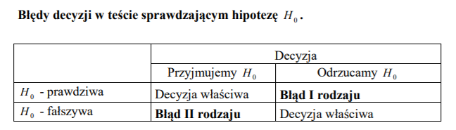

### Testy zgodności

**Testy zgodności**, czyli testy pozwalające na weryfikowanie zgodności obserwowanych danych z zadanym rozkładem ciągłym.

Najpopularniejszą grupą testów są testy weryfikujące zgodność z rozkładem normalnym.

Hipoteza zerowa jest postaci

$H_0 : F \in \{ N(\mu,\sigma):\mu \in R, \sigma\in R_+ \}$,

gdzie $F$ to nieznany rozkład (z którego pochodzą obserwowane wartości $x_i$). Weryfikujemy hipotezę, że rozkład ten należy do rodziny rozkładów normalnych ale nie znamy średniej ani wariancji.

W pakiecie R testy normalności zostały zebrane w pakiecie `nortest`

#### Test Shapiro-Wilka

```r
dane1 <- c(96.19,98.06, 103.45, 99.81, 101.60, 104.33)
shapiro.test(dane1)
```

```
##
##  Shapiro-Wilk normality test
##
## data:  dane1
## W = 0.96209, p-value = 0.8357
```

#### Test Shapiro-Francia

```r
sf.test(dane1)
```

```
##
##  Shapiro-Francia normality test
##
## data:  dane1
## W = 0.97852, p-value = 0.9878
```

> **Zadanie 2** Znajdź inny test na normalność rozkładu i przetestuj przeanalizowany przykład. Jaką minimalną ilość danych potrzebujesz dla wybranego przez siebie testu ?

> **Zadanie 3** Wygeneruj 300 elementowy wektor danych, na którym napewno odrzucisz hipotezę zerową dla testu Shapiro-Wilka.

Do wizualnej oceny normalności można wykorzystać wykres kwantylowy dla rozkładu normalnego `qqnorm()`. Jeżeli obserwacje poczhodzą z rozkładu normalnego, to punkty na wykresie układają się wzdłuż linii prostej (linię tę można dorysować przez polecenie `qqline()`)

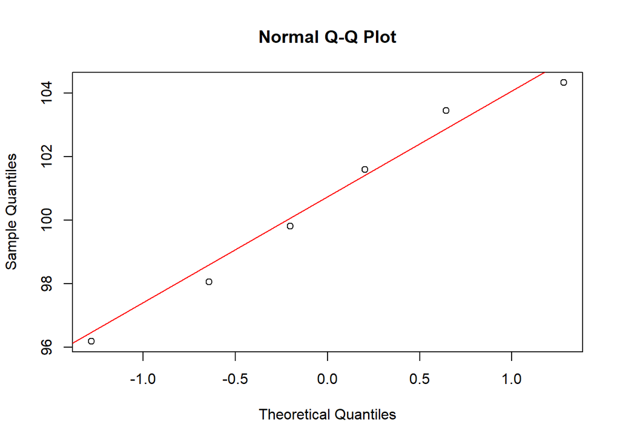

```r
qqnorm(dane1)
qqline(dane1,col="red")
```

### Test zgodności dla dwóch prób

Jednym z najbardziej popularnych testów zgodności dla dwóch prób jest test **Kołomogorowa-Smirnowa**, który w R zawarty jest w funkcji `ks.test()`.

Weryfikuje on hipotezę zerową:

$H_0:F=G$

gdzie $F$ to dystrybuanta (dla nieznanego rozkładu) pierszej próby a $G$ to dystrybuanta (dla nieznanego rozkłądu) drugiej próby.

```r
x<- runif(100)
y<- rnorm(100)
ks.test(x,y)
```

```
##
##  Two-sample Kolmogorov-Smirnov test
##
## data:  x and y
## D = 0.49, p-value = 7.475e-11
## alternative hypothesis: two-sided
```

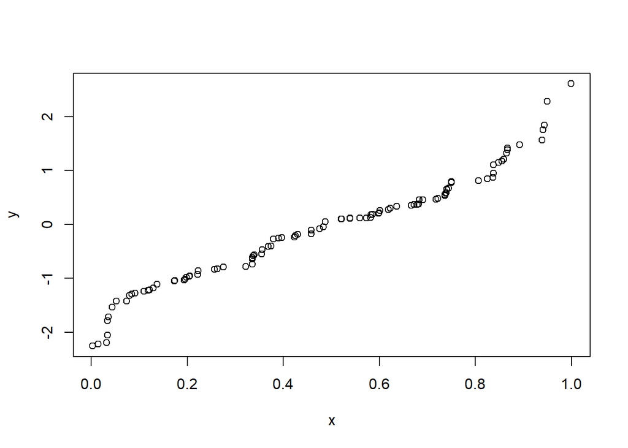

```r
qqplot(x,y)
```

```r
# albo
a<- rnorm(100)
b<- rnorm(100)
ks.test(a,b)
```

```
##
##  Two-sample Kolmogorov-Smirnov test
##
## data:  a and b
## D = 0.08, p-value = 0.9062
## alternative hypothesis: two-sided
```

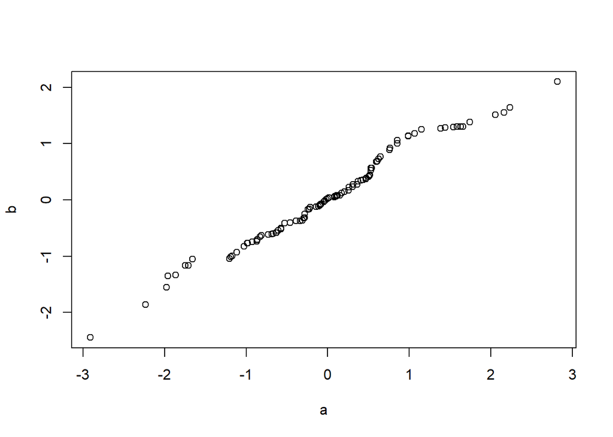

```r
qqplot(a,b)
```

### Testy średniej dla jednej próby

#### Test t-studenta, test Z, test Wilcoxona

`Test t-studenta` pozwala odpowiedzieć na pytanie czy średnia z próby jest statystycznie różna od (znanej, bądź zakładanej) średniej z populacji. W teście tym wariancja badanej populacji **nie** jest znana. Jeśli wariancja jest znana to można zastosować `test Z`. Dla powyższych dwóch testów musimy zweryfikować normalność rozkładu. W przypadku gdy test normalności dał wynik negatywny powinniśmy zastosować test `Wilcoxona`.

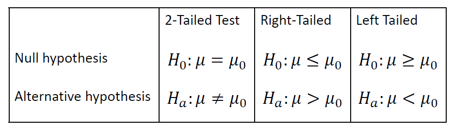

**Analiza zbioru** `dane1`.

```r
t.test(dane1,mu=100)
```

```
##
##  One Sample t-test
##
## data:  dane1
## t = 0.44609, df = 5, p-value = 0.6742
## alternative hypothesis: true mean is not equal to 100
## 95 percent confidence interval:
##   97.26953 103.87714
## sample estimates:
## mean of x
##  100.5733
```

Gdyby rozkład nie był rozkładem normalnym to:

```r
wilcox.test(dane1,mu=100)
```

```
##
##  Wilcoxon signed rank test
##
## data:  dane1
## V = 12, p-value = 0.8438
## alternative hypothesis: true location is not equal to 100
```

> **Zadanie 4** Do podanych na tablicy danych wzrostu Twojej grupy zweryfikuj czy średni wzrost grupy jest równy średniemu wzrostowi w Polsce (180cm).

### Testy dla dwóch prób

Mając do dyspozycji dwa zbiory danych wpierw musimy zweryfikować tzw jednorodność wariancji. Służy do tego test `F-Snedecora`. Następnie możemy porównać czy średnie pochodzą z tej samej populacji korzystając z testu `U-Manna-Whitneya` (gdy rozkłady nie przeszły testu jednorodności wariancji) lub testu `t-studenta` dla dwóch średnich.

```r
dane2 = c(99.7,99.8,102.54,99.32,99.45,103.43)
var.test(dane1,dane2)
```

```
##
##  F test to compare two variances
##
## data:  dane1 and dane2
## F = 3.0751, num df = 5, denom df = 5, p-value = 0.2431
## alternative hypothesis: true ratio of variances is not equal to 1
## 95 percent confidence interval:
##   0.4302955 21.9755225
## sample estimates:
## ratio of variances
##           3.075056
```

```r
t.test(dane1,dane2)
```

```
##
##  Welch Two Sample t-test
##
## data:  dane1 and dane2
## t = -0.090119, df = 7.941, p-value = 0.9304
## alternative hypothesis: true difference in means is not equal to 0
## 95 percent confidence interval:
##  -3.549551  3.282884
## sample estimates:
## mean of x mean of y
##  100.5733  100.7067
```

```r
wilcox.test(dane1,dane2)
```

```
##
##  Wilcoxon rank sum test
##
## data:  dane1 and dane2
## W = 20, p-value = 0.8182
## alternative hypothesis: true location shift is not equal to 0
```

> **Zadanie 5** Zweryfikuj czy średni wzrost w grupie różni się w zależności od płci?

### Testy $\chi^2$ na niezależność

Test ten wykonuje się w celu zbadania związku między dwoma zmiennymi $X$ i $Y$. $H_0$ dla tego testu jest stwierdzenie, iż zmienne $X$ i $Y$ są niezależne. Test ten bazuje tylko na porównaniu ze sobą wartości obserwowanych oraz wartości teoretycznych (obliczonych przy założeniu, że między zmiennymi nie ma żadnego związku). Zmienne $X$ i $Y$ zmieniają się na kilku poziomiach.

**Przykład** Zadano pacjentom pytanie “Czy antybiotyki działają na wirusy?”, natomiast odpowiadający odpowiadali “Tak”,“Nie”,“Nie wiem”.

Otrzymaliśmy następujące odpowiedzi:

|  | Nie | Nie wiem | Tak |
| --- | --- | --- | --- |
| Kobieta | 2789 | 770 | 455 |
| Mężczyzna | 2243 | 744 | 389 |

Weryfikacja testu pozwoli odpowiedzieć na pytanie czy rodzaj odpowiedzi ma związek z płcią pacjenta?

Aby odpowiedzieć na to pytanie musimy wykonać test $\chi^2$.

```r
kob <- c(2789,770,455)
men <- c(2243,744,389)
chisq.test(cbind(kob,men))
```

```
##
##  Pearson's Chi-squared test
##
## data:  cbind(kob, men)
## X-squared = 9.8447, df = 2, p-value = 0.007282
```

Zatem na poziomie istotności $\alpha=0.05$ odrzucamy hipotezę zerową. Co oznacza, że zmienne nie są niezależne.

> **Zadanie 6** Pewien produkt można wytworzyć trzema metodami produkcji. Wysunięto hipotezę, że wadliwość produkcji nie zależy od metody produkcji. W wylosowanej niezależnie próbie 270 sztuk otrzymano następujące wyniki:

| jakosc | I | II | III |
| --- | --- | --- | --- |
| Dobra | 40 | 80 | 60 |
| Zła | 10 | 60 | 20 |

> Czy na poziomie $\alpha=0.05$ jakość produkcji nie zależy od metody?

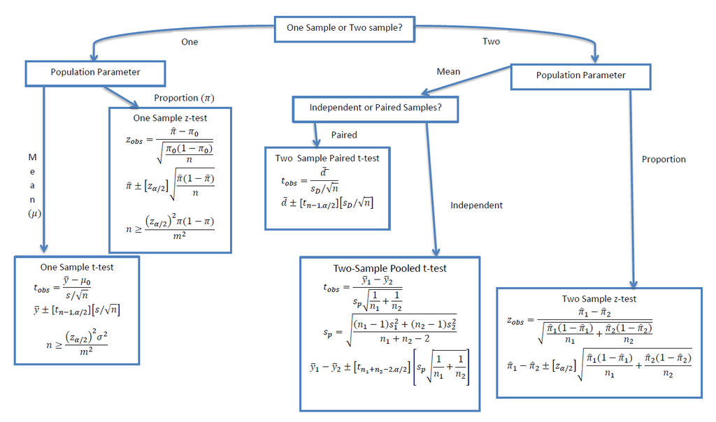